# pre-class

Make sure you commit this often with meaningfull messages.

### Background

The exponential distribution is defined by its cumulative distribution function $F(x) = 1-e^{-\lambda x}$

The R function *rexp()* generates random variables with an exponential distribution. For example

**rexp(n=10, rate=5)**

results in 10 exponentially distributed numbers with a rate $\lambda=5$. If you leave out the 5 and just have

**rexp(n=10)**

then this results in 10 exponentially distributed numbers with a rate $\lambda=1$, this is also referred to as the “standard exponential distribution”.

### Part 1

1. Generate 200 random values from the standard exponential distribution and store them in a vector `exp.draws.1`. Find the mean and standard deviation of `exp.draws.1`.

```r
#This vector holds 200 random values from the standard exponential distribution.
exp.draws.1 <- rexp(n = 200)
#This is the calculation of the mean and standard deviation of the just created vector.
mean(exp.draws.1)
```

```
## [1] 1.052353
```

```r
sd(exp.draws.1)
```

```
## [1] 1.066814
```

2. Repeat, but change the rate to 0.2, 5, 7.3 and 10, storing the results in vectors called `exp.draws.0.2`, `exp.draws.5`, `exp.draws.7.3` and `exp.draws.10`.

```r
#The following vectors hold 200 random values from the exponential distribution with varying rate, with their means and standard deviations calculated.

#With rate = 0.2
exp.draws.0.2 <- rexp(n = 200, rate = 0.2)
mean(exp.draws.0.2)
```

```
## [1] 4.888
```

```r
sd(exp.draws.0.2)
```

```
## [1] 5.150045
```

```r
#With rate = 5
exp.draws.5 <- rexp(n = 200, rate = 5)
mean(exp.draws.5)
```

```
## [1] 0.1859359
```

```r
sd(exp.draws.5)
```

```
## [1] 0.1944546
```

```r
#With rate 7.3
exp.draws.7.3 <- rexp(n = 200, rate = 7.3)
mean(exp.draws.7.3)
```

```
## [1] 0.134434
```

```r
sd(exp.draws.7.3)
```

```
## [1] 0.1416471
```

```r
#With rate 10
exp.draws.10 <- rexp(n = 200, rate = 10)
mean(exp.draws.10)
```

```
## [1] 0.09686829
```

```r
sd(exp.draws.10)
```

```
## [1] 0.1044963
```

3. The function `plot()` is the generic function in R for the visual display of data. `hist()` is a function that takes in and bins data as a side effect. To use this function, we must first specify what we’d like to plot.
   1. Use the `hist()` function to produce a histogram of your standard exponential distribution.

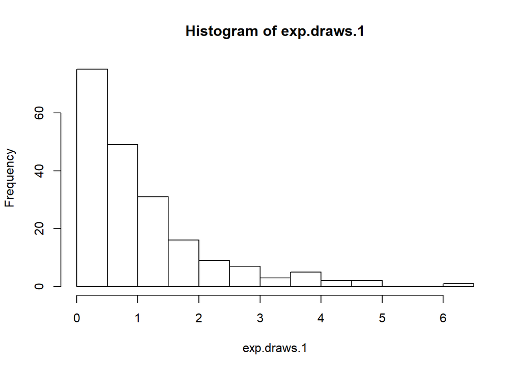

```r
# Histogram of results from the generated random values from the standard exponential distribution.
hist(exp.draws.1)
```

*The histogram tells you how many of the generated random values fall into a given interval.*

2. Use `plot()` with this vector to display the random values from your standard distribution in order.

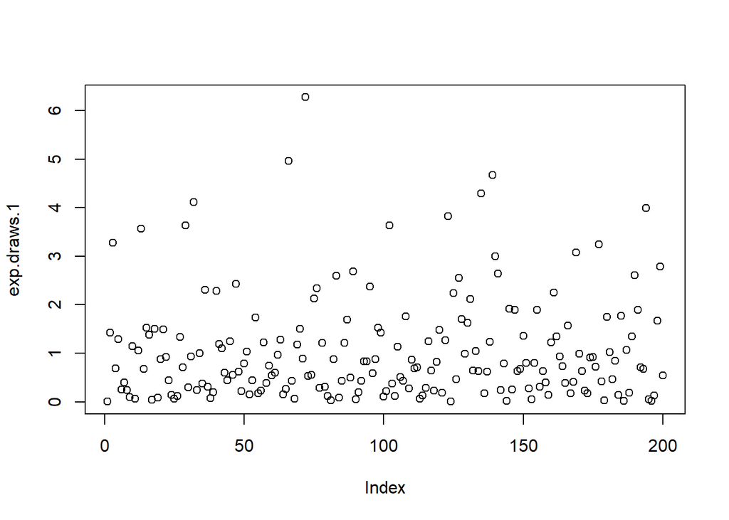

```r
#Plot of the generated random values from the standard exponential distribution.
plot(exp.draws.1)
```

*In this plot, the index of the simulated value is plotted against its value. Most of the values are less than 1, as you would expect from the histogram plot.*

3. Now, use `plot()` with two arguments – any two of your other stored random value vectors – to create a scatterplot of the two vectors against each other.

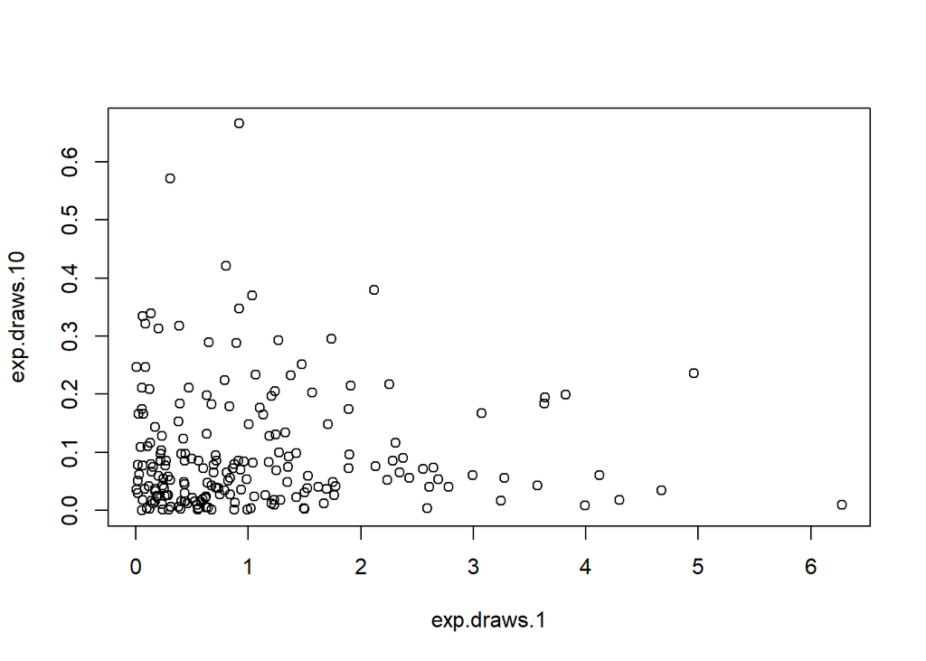

```r
plot(exp.draws.1, exp.draws.10)
```

*For a given index i, this graphic plots the ith simulated value of the standard exponential distribution against the ith simulated value of the exponential distribution with rate equal to 10.*

4. We’d now like to compare the properties of each of our vectors. Begin by creating a vector of the means of each of our five distributions in the order we created them and saving this to a variable name of your choice. Using this and other similar vectors, create the following scatterplots and explain in words what is going on:
   1. The five means versus the five rates used to generate the distribution.

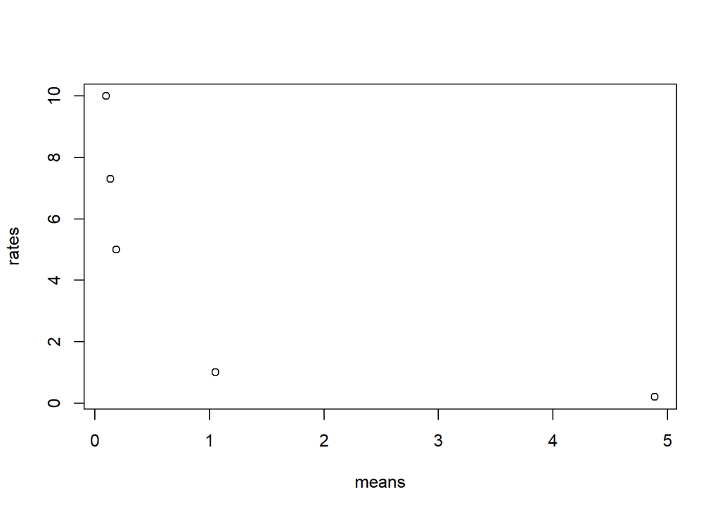

```r
#This vector contains the values for the rates used to generate the random values.
rates <- c(1, 0.2, 5, 7.3, 10)
#This vector contains the means of the five sets of simulated values.
means <- c(mean(exp.draws.1), mean(exp.draws.0.2), mean(exp.draws.5), mean(exp.draws.7.3), mean(exp.draws.10))
#This vector contains the standard deviations of the five sets of simulated values.
sds <- c(sd(exp.draws.1), sd(exp.draws.0.2), sd(exp.draws.5), sd(exp.draws.7.3), sd(exp.draws.10))
#This is a plot of the five means versus the five rates used to generate the values.
plot(means, rates)
```

*Each of the vectors of generated random values was created from the exponential distribution set at a different rate. This plot connects the mean of the generated random values to the rate they were generated with. The value of the means are all close to 1 divided by the rate they were generated with, which is understandable since the expected value of the exponential distribution is 1 divided by the parameter, which is called the rate in this context.*

2. The standard deviations versus the rates.

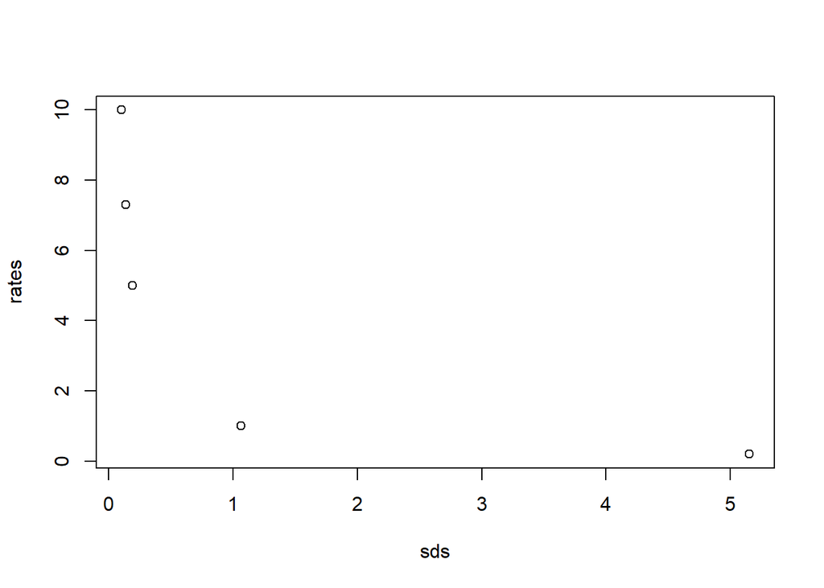

```r
#This is a plot of the standard deviations versus the rates.
plot(sds, rates)
```

*Instead of associating the mean of the generated random values to the rate they were generated with, the plot associates the standard deviation to the rate. This graph looks quite similar to the previous one, since for the exponential distribution, the expected value is equal to the standard deviation (which again, is 1 divided by the rate).*

3. The means versus the standard deviations.

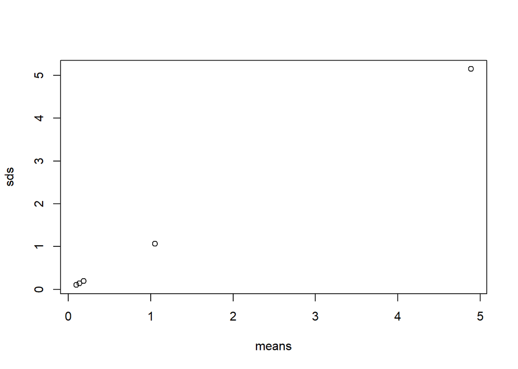

```r
#This is a plot of the means versus the standard deviations.
plot(means, sds)
```

*This graphic plots the means of the vectors of generated values to the standard deviations of the same vectors. As previously stated, for the exponential distribution the expected value is equal to the standard deviation. Thus, the closest straight line to match this graph would be quite similar to the identity line y = x.*

### Part II (PHP 2560 Only)

5. R’s capacity for data and computation is large to what was available 10 years ago.
   1. To show this, generate 1.1 million numbers from the standard exponential distribution and store them in a vector called `big.exp.draws.1`. Calculate the mean and standard deviation.

```r
#This vector contains 1.1 million values generated from the standard exponential distribution. The mean and standard deviation are then calculated.
big.exp.draws.1 <- rexp(n = 1100000)
mean(big.exp.draws.1)
```

```
## [1] 1.000436
```

```r
sd(big.exp.draws.1)
```

```
## [1] 1.000227
```

2. Plot a histogram of `big.exp.draws.1`. Does it match the function $1-e^{-x}$? Should it?

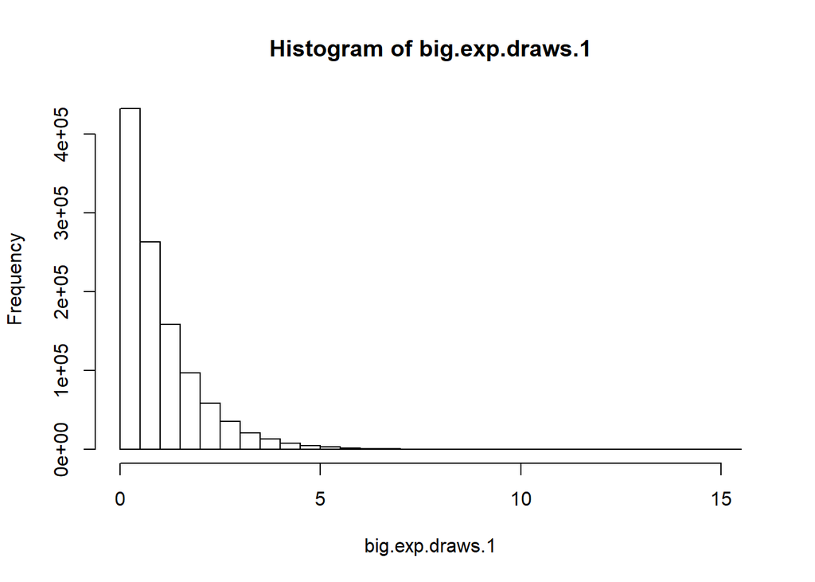

```r
#This is a histogram of the vector of values generated in the previous part of this problem.
hist(big.exp.draws.1)
```

*The histogram clearly does not match the function* $1 - e^{-x}$ *since that function is 0 when x = 0, but the histogram is not near 0 for the box containing 0. Furthermore,* $1 - e^{-x}$ *is an increasing function, but the histogram boxes get smaller and smaller.*

*Instead, the function that the histogram resembles is* $e^{-x}$ *, which makes sense, since* $e^{-x}$ *is the pdf for the standard exponential distribution. The size of the histogram bin is proportional to the number of elements in the vector, and so each histogram bin gives you a visualization of the probability that a simulated value will be in the interval represented by the bin. This is akin to the fact that the integral of the pdf over an interval gives you the probability of a random value being within that interval.*

*Finally, the histogram should not resemble* $1 - e^{-x}$ *, since that is the CDF of the exponential distribution, which tells you the probability that a simulated value will be less than* $x$ *- this is not relevant to the histogram.*

3. Find the mean of all of the entries in `big.exp.draws.1` which are strictly greater than 1. You may need to first create a new vector to identify which elements satisfy this.

```r
#This vector selects only the generated values that are greater than 1, then the mean is calculated.
big.exp.draws.1.greater <- big.exp.draws.1[big.exp.draws.1 > 1]
mean(big.exp.draws.1.greater)
```

```
## [1] 1.999727
```

4. Create a matrix, `big.exp.draws.1.mat`, containing the the values in `big.exp.draws.1`, with 1100 rows and 1000 columns. Use this matrix as the input to the `hist()` function and save the result to a variable of your choice. What happens to your data?

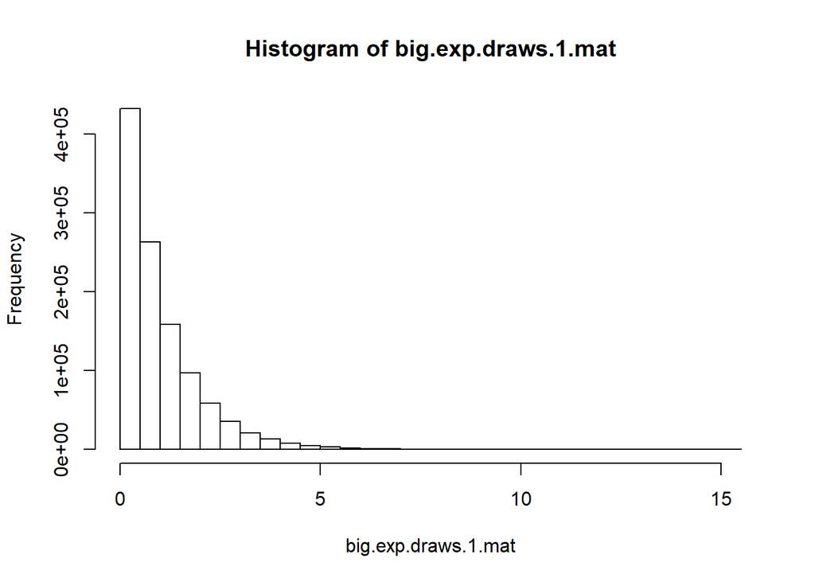

```r
#This matrix contains the simulated data, and stores it in 1100 rows and 1000 columns. A histogram is then generated from the matrix data.
big.exp.draws.1.mat <- matrix(big.exp.draws.1, nrow = 1100, ncol = 1000)
hist(big.exp.draws.1.mat)
```

*The histogram produced is the same as the histogram in part (b), since the histogram function simply treats the matrix as a vector.*

5. Calculate the mean of the 371st column of `big.exp.draws.1.mat`.

```r
#The mean of the 371st column of the previous generated matrix is calculated.
mean(big.exp.draws.1.mat[, 371])
```

```
## [1] 1.024854
```

6. Now, find the means of all 1000 columns of `big.exp.draws.1.mat` simultaneously. Plot the histogram of column means. Explain why its shape does not match the histogram in problem 5b).

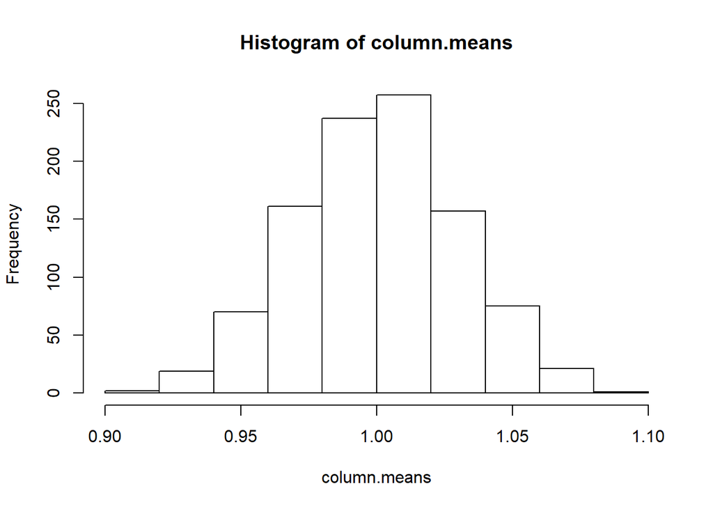

```r
#This vector contains the means of each column in the previously generated matrix.
column.means <- colMeans(big.exp.draws.1.mat)
#Histogram of the column means.
hist(column.means)
```

*The shape does not match that of the histogram from part (b) because instead of the data being simulated values of the standard exponential distribution, each data point is the mean of 1100 of these simulated values. Since the expected value of the standard exponential distribution is 1, we expect that these values should group around 1, which they in fact do. The shape of the histogram is beginning to resemble a normal distribution, with a mean of 1.*